# Distancier des UNV Alsace

JcB & RESURAL

24/11/2015

# Création d’un distancier entre les communes d’Alsace et les UNV

Il y a quatre UNV en Alsace dans les communes de Haguenau, Strasbourg, Colmar et Mulhouse. L’UNV de Haguenau fonctionne par intermittence faute d’effectifs médicaux suffisants.

source méthodologique: [cartography](https://elementr.hypotheses.org/284) sur le site [RGeomatic](http://rgeomatic.hypotheses.org/659).

## Création des fichiers de base

On utilise:

- fichier des communes avec la geoloc du centre ville: **villes_alsace_gps.csv**
- fichier des geoloc des UNV: **UNV.csv** (Alsace et Lorraine)
- création de la matrice des temps (en mn) avec **osrmTableOD**. Cette fonction est limitée à 100 communes par appel => il faut prévoir une boucle pour toutes les faire.

Le fichier créé est enregistré au format *csv* (distancier_unv_alsace.csv) et le programme qui le crée est désactivé pour ne pas solliciter inutilement le serveur. En cas d’upgrade, il faudra le réactiver.

```
library(osrm)

file1 <- "villes_alsace_gps.csv"
file2 <- "UNV.csv"

villes <- read.csv(file1)
unv <- read.csv(file2)

# Certaines ville n'ont pas de coordonnées GPS. Sur les 907 communes, il en reste 861
villes2 <- villes[complete.cases(villes),]
# le nombre de requêtes est limité à 100

# colonne code_insee

n <- nrow(villes2)
d1 <- NULL
i <- 1
j <- 1
k <- 90
while(i < n){

    d <- osrmTableOD(villes2[j:k,], "nom_commune", xo = "longitude", yo = "latitude", dfd = unv, idd = "UNV", xd = "X", yd = "Y")
    d1 <- rbind(d1, d)
    j <- k + 1
    k <- k + 90
    if(k > n)
        k = n
    i = k
}
# une boucle supplémentaire pour les dernières villes
d <- osrmTableOD(villes2[j:k,], "nom_commune", xo = "longitude", yo = "latitude", dfd = unv, idd = "UNV", xd = "X", yd = "Y")
d1 <- rbind(d1, d)

names(d1)[1] <- "ville"
write.csv(d1, file <- "distancier_unv_alsace.csv")
```

## Communes manquantes dans le 67

```
 [1] ANDLAU                     BALBRONN                   BOUXWILLER                 BUHL
 [5] CRASTATT                   DRACHENBRONN-BIRLENBACH    EBERBACH-SELTZ             WANGENBOURG-ENGENTHAL
 [9] GRIESHEIM-SUR-SOUFFEL      NEUGARTHEIM-ITTLENHEIM     JETTERSWILLER              KIRRWILLER
[13] MULHAUSEN                  NEEWILLER-PRES-LAUTERBOURG NEUVILLER-LA-ROCHE         BETSCHDORF
[17] OBERHOFFEN-LES-WISSEMBOURG OBERMODERN-ZUTZENDORF      SEEBACH                    RANRUPT
[21] ROPPENHEIM                 SCHARRACHBERGHEIM-IRMSTETT SCHWEIGHOUSE-SUR-MODER     SCHWENHEIM
[25] STUTZHEIM-OFFENHEIM        THAL-DRULINGEN             THAL-MARMOUTIER            WESTHOUSE
[29] WESTHOUSE-MARMOUTIER       WICKERSHEIM-WILSHAUSEN     ZOEBERSDORF
```

Sélection de l’UNV la plus proche. On ajoute une colonne ‘choix’. NB: le fichier d1 (communes + temps de trajet en minutes) a été créé à l’étape précédente.

## Calcul des temps de trajet par commune

### UNV d’Alsace (temps de trajet en minutes)

| nom_commune | HTP | CH.Haguenau | CH.Colmar | CH.Mulhouse |
| --- | --- | --- | --- | --- |
| Bartenheim | 75.8 | 94.7 | 37.4 | 21.3 |
| Diebolsheim | 38.1 | 56.9 | 44.0 | 65.9 |
| Rauwiller | 49.1 | 45.2 | 91.1 | 114.2 |
| Moosch | 88.4 | 107.3 | 43.5 | 30.7 |
| Strasbourg | 6.4 | 23.0 | 52.5 | 75.6 |
| Bernardswiller | 23.2 | 42.1 | 35.5 | 58.6 |
| Gerstheim | 25.7 | 44.6 | 46.4 | 69.5 |
| Meistratzheim | 21.5 | 40.3 | 38.8 | 61.9 |
| Dachstein | 18.8 | 38.8 | 45.6 | 68.7 |
| Duttlenheim | 17.1 | 36.0 | 38.0 | 61.1 |
| Fouday | 48.6 | 67.4 | 52.9 | 76.0 |
| Gresswiller | 25.1 | 44.0 | 45.5 | 68.5 |
| Marlenheim | 16.5 | 36.5 | 52.1 | 75.2 |
| Oberhaslach | 33.8 | 52.7 | 54.2 | 77.3 |
| Rothau | 43.5 | 62.3 | 58.5 | 81.6 |
| Solbach | 51.2 | 70.1 | 55.5 | 78.6 |
| Triembach-au-Val | 37.3 | 56.2 | 29.4 | 52.5 |
| Bischholtz | 43.0 | 29.9 | 89.1 | 112.2 |
| Bust | 45.6 | 41.7 | 87.6 | 110.7 |
| Durstel | 52.4 | 48.5 | 94.4 | 117.5 |
| Hohengoeft | 24.8 | 30.6 | 59.0 | 82.1 |
| Hohfrankenheim | 22.7 | 19.9 | 71.0 | 94.1 |
| Ringendorf | 27.5 | 23.4 | 73.6 | 96.7 |
| Schaffhouse-sur-Zorn | 21.5 | 20.6 | 70.6 | 93.6 |
| Siltzheim | 64.9 | 61.0 | 106.9 | 130.0 |
| Uttwiller | 32.1 | 28.2 | 78.2 | 101.3 |
| Waldhambach | 58.9 | 54.9 | 101.2 | 124.3 |
| Zittersheim | 52.7 | 48.8 | 98.8 | 121.9 |
| Gumbrechtshoffen | 36.0 | 20.3 | 82.1 | 105.2 |
| Ingolsheim | 43.6 | 25.8 | 89.7 | 112.8 |

[output cut: 828 more lines]

### UNV hors Alsace (temps de trajet en minutes)

| nom_commune | CH.Belfort | CH.Epinal | Bar.le.Duc | CH.Forbach | CH.Metz..Mercy. | CHU.Nancy..Central. |
| --- | --- | --- | --- | --- | --- | --- |
| Bartenheim | 42.0 | 104.8 | 197.9 | 139.6 | 160.4 | 143.0 |
| Diebolsheim | 84.1 | 116.3 | 181.4 | 104.6 | 125.3 | 126.4 |
| Rauwiller | 132.4 | 100.1 | 125.5 | 47.6 | 68.4 | 70.6 |
| Moosch | 37.9 | 65.5 | 160.5 | 152.2 | 141.7 | 104.3 |
| Strasbourg | 93.8 | 121.7 | 153.1 | 70.7 | 91.4 | 98.2 |
| Bernardswiller | 76.8 | 104.7 | 168.3 | 85.9 | 106.6 | 113.4 |
| Gerstheim | 87.7 | 115.6 | 174.7 | 92.2 | 113.0 | 119.7 |
| Meistratzheim | 80.1 | 108.0 | 167.7 | 85.3 | 106.0 | 112.8 |
| Dachstein | 86.9 | 114.6 | 155.5 | 73.1 | 93.8 | 100.6 |
| Duttlenheim | 79.3 | 107.2 | 163.7 | 81.2 | 102.0 | 108.7 |
| Fouday | 94.2 | 79.0 | 136.2 | 102.8 | 117.4 | 81.2 |
| Gresswiller | 86.8 | 106.1 | 161.2 | 78.8 | 99.5 | 106.3 |
| Marlenheim | 93.4 | 119.0 | 147.1 | 64.7 | 85.4 | 92.2 |
| Oberhaslach | 95.5 | 102.7 | 159.9 | 79.4 | 100.1 | 104.9 |
| Rothau | 99.8 | 85.1 | 142.3 | 97.7 | 118.5 | 87.4 |
| Solbach | 96.8 | 82.6 | 139.8 | 105.5 | 121.0 | 84.8 |
| Triembach-au-Val | 70.7 | 88.0 | 153.1 | 101.2 | 121.9 | 98.1 |
| Bischholtz | 130.4 | 133.2 | 158.7 | 73.9 | 94.7 | 103.7 |
| Bust | 128.9 | 106.1 | 131.5 | 42.6 | 63.4 | 76.6 |
| Durstel | 135.7 | 112.9 | 138.4 | 40.6 | 61.3 | 83.4 |
| Hohengoeft | 100.3 | 117.0 | 142.4 | 60.0 | 80.8 | 87.5 |
| Hohfrankenheim | 112.3 | 118.3 | 143.7 | 61.3 | 82.0 | 88.8 |
| Ringendorf | 114.9 | 120.2 | 145.6 | 63.2 | 83.9 | 90.7 |
| Schaffhouse-sur-Zorn | 111.9 | 117.9 | 143.3 | 60.9 | 81.7 | 88.4 |
| Siltzheim | 148.2 | 127.8 | 134.2 | 25.0 | 53.7 | 90.8 |
| Uttwiller | 119.5 | 120.3 | 145.8 | 62.8 | 83.6 | 90.8 |
| Waldhambach | 142.5 | 119.7 | 145.2 | 44.3 | 65.0 | 90.2 |
| Zittersheim | 140.1 | 123.8 | 149.2 | 57.4 | 78.2 | 94.3 |
| Gumbrechtshoffen | 123.4 | 131.8 | 157.3 | 74.8 | 95.6 | 102.3 |
| Ingolsheim | 131.0 | 143.6 | 169.1 | 86.6 | 107.4 | 114.1 |

[output cut: 828 more lines]

## Meilleurs choix avec Haguenau (choix) et sans Haguenau (choix 2)

| nom_commune | choix | choix2 |
| --- | --- | --- |
| Bartenheim | CH.Mulhouse | CH.Mulhouse |
| Diebolsheim | HTP | HTP |
| Rauwiller | CH.Haguenau | CH.Forbach |
| Moosch | CH.Mulhouse | CH.Mulhouse |
| Strasbourg | HTP | HTP |
| Bernardswiller | HTP | HTP |
| Gerstheim | HTP | HTP |
| Meistratzheim | HTP | HTP |
| Dachstein | HTP | HTP |
| Duttlenheim | HTP | HTP |
| Fouday | HTP | HTP |
| Gresswiller | HTP | HTP |
| Marlenheim | HTP | HTP |
| Oberhaslach | HTP | HTP |
| Rothau | HTP | HTP |
| Solbach | HTP | HTP |
| Triembach-au-Val | CH.Colmar | CH.Colmar |
| Bischholtz | CH.Haguenau | HTP |
| Bust | CH.Haguenau | CH.Forbach |
| Durstel | CH.Forbach | CH.Forbach |
| Hohengoeft | HTP | HTP |
| Hohfrankenheim | CH.Haguenau | HTP |
| Ringendorf | CH.Haguenau | HTP |
| Schaffhouse-sur-Zorn | CH.Haguenau | HTP |
| Siltzheim | CH.Forbach | CH.Forbach |
| Uttwiller | CH.Haguenau | HTP |
| Waldhambach | CH.Forbach | CH.Forbach |
| Zittersheim | CH.Haguenau | HTP |
| Gumbrechtshoffen | CH.Haguenau | HTP |
| Ingolsheim | CH.Haguenau | HTP |

[output cut: 828 more lines]

Forbach et Belfort sont un meilleur choix pour 88 communes d’Alsace si Hagueanu est actif et un meilleur choix pour 95 communes d’Alsace si Haguenau ne fonctonne pas.

# Fichier mergé

Le fichier **dist** resulte du merging du fichier des disances **d1** et du fichier **villes2** dont on ne conserve que certaines colonnes. On récupère ainsi des infos utiles comme le code INSEE de la commune.

```
## 'data.frame':    869 obs. of  18 variables:
##  $ nom_commune        : Factor w/ 902 levels "Achenheim","Adamswiller",..: 1 2 3 4 5 6 7 8 9 10 ...
##  $ numéro_département : int  67 67 67 68 67 67 68 67 68 67 ...
##  $ codes_postaux      : int  67204 67320 67220 68600 67310 67270 68210 67490 68130 67120 ...
##  $ code_insee         : int  67001 67002 67003 68001 67004 67005 68002 67006 68004 67008 ...
##  $ latitude           : num  48.6 48.9 48.4 48 48.7 ...
##  $ longitude          : num  7.63 7.2 7.32 7.57 7.38 ...
##  $ HTP                : num  8.3 56.5 39.3 61 25.1 22.3 90.6 28.4 88.6 20.9 ...
##  $ CH.Haguenau        : num  28.4 52.6 58.2 79.8 32.8 ...
##  $ CH.Colmar          : num  50.3 98.5 32.8 22.8 59.1 68.4 48.8 66.8 49.8 40.4 ...
##  $ CH.Mulhouse        : num  73.4 121.6 55.9 39.6 82.1 ...
##  $ CH.Belfort         : num  91.6 139.8 74.1 57.8 100.4 ...
##  $ CH.Epinal          : num  119.5 117 87.3 108.7 112.4 ...
##  $ Bar.le.Duc         : num  157 142 152 183 138 ...
##  $ CH.Forbach         : num  74.4 41.6 103.1 124.8 55.4 ...
##  $ CH.Metz..Mercy.    : num  95.2 62.3 123.9 145.6 76.2 ...
##  $ CHU.Nancy..Central.: num  101.9 87.5 97.4 128.1 82.9 ...
##  $ choix              : chr  "HTP" "CH.Forbach" "CH.Colmar" "CH.Colmar" ...
##  $ choix2             : chr  "HTP" "CH.Forbach" "CH.Colmar" "CH.Colmar" ...
```

## Création d’une colonne de couleur par commune

### Cartographie du Bas-Rhin

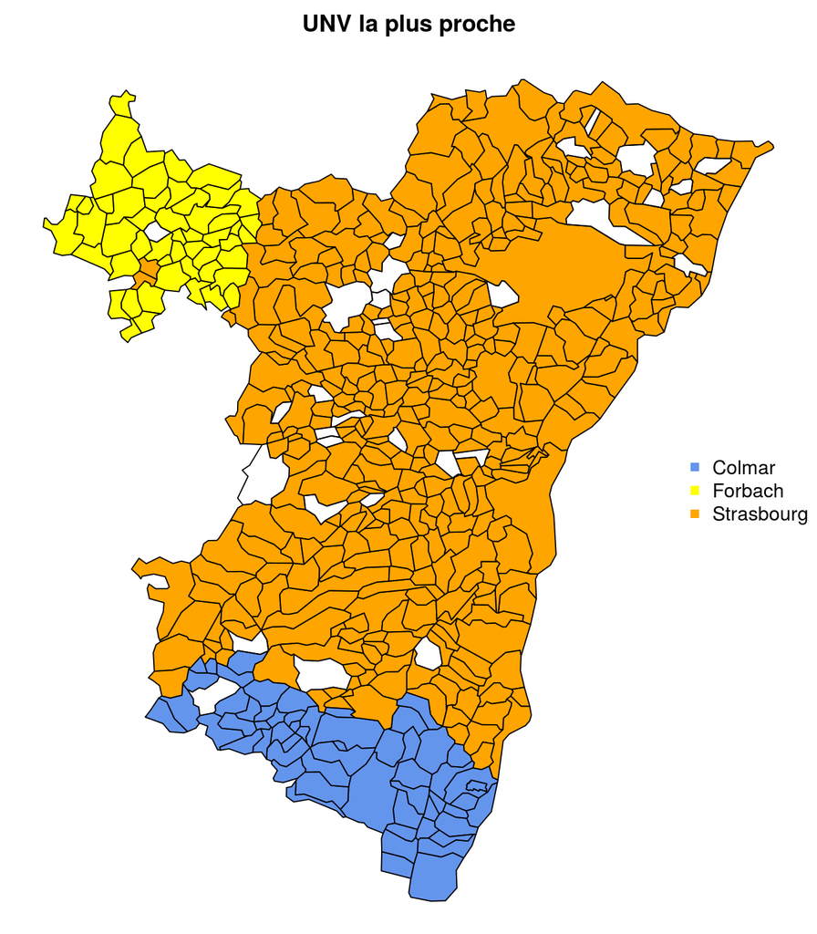

### Cartographie du Haut-Rhin

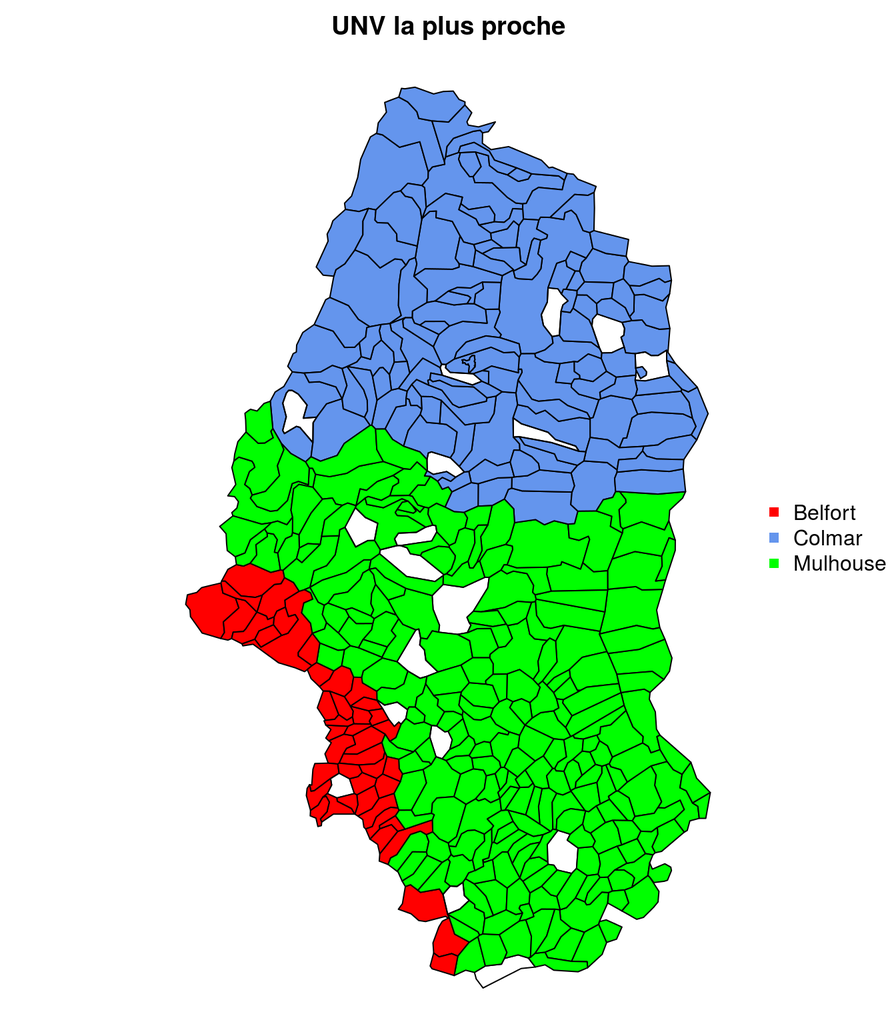

# Cartographie

Ulilise le fond de carte dynanmique fournit par OpenStreetMap. Ne fonctionne qu’avec une page HTML (web).

[interactive chart not shown]